# DATA 220G Spring 2018

| Course: | DATA220G - Data Analysis with R |
| --- | --- |
| Semester: | Spring 2018 |
| Instructor: | Bob Rudis |
| Contact Email: | rrudis@ccsnh.edu |
| Day/Time: | Online |
| Office hours: | By appointment (virtual) |
| Textbook: | R for Data Science / Advanced R (see below) |

# Catalog Description (adjusted)

This course is an applied data science & statistics course that introduces students to key, modern topics in including data acquisition, data exploration, statistical data analysis and communicating the results of data analyses. Major topics include advanced R programming language concepts, working as a standalone data analyst and within a team, organizing analysis projects, finding data on the internet, web scraping & APIs, and a survey of modeling, clustering, classification and time series analysis and forecasting tools & techniques. Prerequisites: C or better in DATA210G (or by department approval) and MATH235G (may be co-requisite).

# Desired Student Competencies

Students will:

- Produce data analysis projects from start to finish individually and as a team.
- Ask and answer key questions from data sources provided or selected.
- Communicate results clearly through text, code and visualizations.
- Validate findings with basic statistics and machine learning techniques.
- Show proficiency using version control systems.

# Grading/Assessment

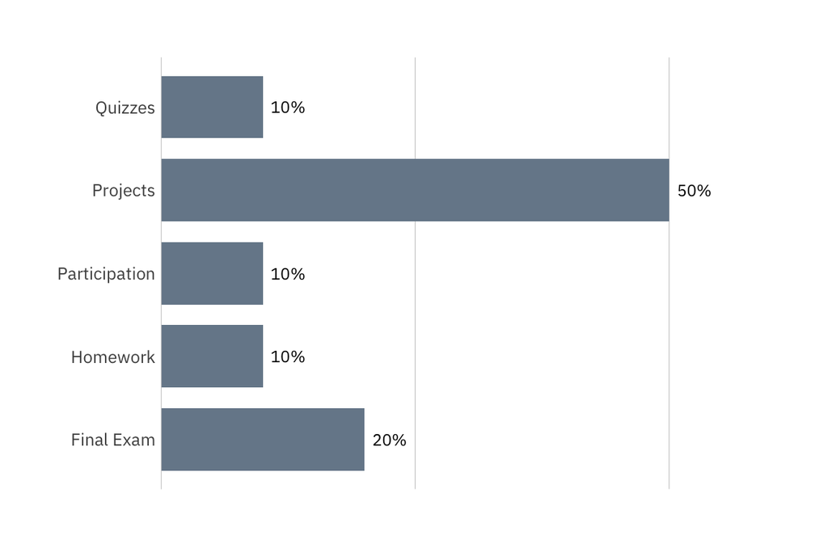

# College Email

I send all class announcements to you at your college email address through Blackboard/Canvas. You are responsible to check your college email regularly for any and all communication sent to you. Email addresses can be found at the Student Information (SIS) site. Any official correspondence (i.e. notification of absence, withdrawal, etc) not using college email is subject to quarantine and/or removal from the CCSNH email server and will not be answered. If there are technical questions (apart from accessing the RStudio Server setup for the class) that need to be answered, please access the helpdesk. The address is http://greatbay.edu/helpdesk. Personal email addresses cannot be used because SIS and Blackboard/Canvas are not set up to accommodate them. I check email regularly and will do my best to reply to your email within 24 hours. Again, I only reply to official email from your college address.

# Class Time

Class will be instruction, homework/project review and discussion of new projects. The class will be delivered remotely and the instructor will be available for ad-hoc office hours as needed. The instructor will also work out a 1:1 weekly online “check-in” schedule with the students to ensure there is a dedicated time to answer questions.

# Student Essentials

- You must return the pre-assessment questionnaire the same day within 48 hours as it will determine the content of the full syllabus for the semester. The level of depth for each topic in the course is highly dependent upon the answers to the assessment. You are not being graded on the assessment, and answering it completely and honestly will enable you to derive the most benefit from the course.
- You must have access to a working version of R and RStudio. I will be using the 3.4.x series of R and the “Preview” edition of RStudio, but the standard installation of RStudio should be fine. The following resources are available to help you install them:
  - [Install R & RStudio](http://stat545.com/block000_r-rstudio-install.html)
  - [Basic intro to working in R & RStudio](http://stat545.com/block002_hello-r-workspace-wd-project.html)
  - [Install Rtools for Windows](https://github.com/stan-dev/rstan/wiki/Install-Rtools-for-Windows) (for those unfortunate enough to be running Windows systems)
- I will be sending out a link to individual logins to a 24x7 (barring internet or cloud provider outages) internet-accessible RStudio Server. This is the “no excuses” R programming environment for the course. You *are not required* to use this server *but* you cannot use issues with your local R installation as an excuse for turning in assignments, quizzes or tests late.
- **YOU ABSOLUTELY WILL NEED** a free [GitHub](http://github.com/) account. You must set one up by the end of the first week of class if you do not have one already. You will be creating a separate, public repository for each homework or project, creating “releases” and submitting the releases to BB/Canvas along with a link to the repository. These repositories must exist for the entire semester as some will build upon others. Individuals who have moral/ethical/etc concerns with GitHub may choose to use other services such as [Bitbucket](https://bitbucket.org/) or [GitLab](https://about.gitlab.com/) account. The following resources are available to help you get working with GitHub & R/RStudio on all platforms:
  - [Happy Git & GitHub for the useR](http://happygitwithr.com/)

# Attendance/Participation Policy

Videos will be made and posted online. You are responsible for viewing the content. If there are any issues with the content or accessing the content you are responsible for notifying the instructor when you encounter the issue.

# Registrar Procedures Add/Drop Deadlines and Procedures:

Please see the official Planning Calendar (available in all the usual places you’re familiar with) for deadlines with the registrar: deadline to drop with full refund, deadline to drop with a “W”, and deadline to drop with “WP/WF”.

In order to drop this class you must fill out an add/drop form and return this form to the One Stop office for processing. Simply ceasing to attend class or contacting the instructor does not constitute officially dropping the course.

**If you are receiving Financial Aid, you should speak with that office before deciding to withdraw.**

You may withdraw from the course and receive the grade of W, which does not impact your GPA (see Planning Calendar on the last page for this deadline date). No signature from the instructor is required. If past this deadline, the next option is to drop with a “WP/WF”. This option does require an instructor signature and can affect GPA.

# Classroom Decorum/Code of Conduct

In order to create a healthy and productive learning environment there are expectations of all of us. These include:

- Civility in behavior and respect for the rights and opinions of others seeking to learn is highly valued. Please be courteous and respectful at all times. When disagreeing with another’s point of view, no belittling, condemnation or put-downs will be tolerated; keep all comments constructive and helpful in nature.
- It is expected that students will be respectful of GBCC staff and GBCC students. GBCC has a no bullying policy. The Student Code of Conduct can be found in the Student Handbook. The handbook can be found on the College website. Students are responsible for being familiar with the Student Code of Conduct.
- It is expected that we will behave in a manner that is ethically consistent with college policy and in a manner that could not be interpreted as cheating or plagiarism.
- The college defines Plagiarism as, “the intentional or unintentional failure to immediately, accurately, and completely cite and document the source of any language, ideas, summaries, hypotheses, conclusions, interpretations, speculations, graphs, charts, pictures, etc., or other material not entirely your own. This includes failure to cite work of your own that you have used previously.”
- Cheating is defined as using or attempting to use unauthorized materials, information, or study aids in any academic exercise or activity. Failure to meet this expectation could result in a grade of F for the course.
- Consequences for acts of plagiarism and/or cheating result in a minimum of 0 for that assignment/quiz/test and maximum of F for the course, depending on the severity of the infringement of the policy.
- I welcome and encourage your input intended to improve the quality of your educational experience.

# Weather Alerts

If school is cancelled for any reason, you should receive an email and/or a phone message from GBCC alerting you. Sign up for “weather alerts” online if you would like a text message. The text messaging service is called “GBCC Alerts” and you will find information to register here: [GBCC Alerts](http://greatbay.edu/campus-life/notifications-announcements)

This should not apply to us.

# Cancellations

If an emergency arises, I will notify Academic Affairs that any scheduled interactive sessions will be cancelled and I will send you an email to your college email address via BB/Canvas.

# Student Support and CAPS

The College is committed to providing support for students with disabilities. Any student with physical, learning, attention, and/or psychological disabilities is encouraged to visit the Center for Academic Planning and Support (CAPS) and make an appointment with the Coordinator of Disability Support Services. More information is available at http://greatbay.edu/student-services/academic-support/disability-services

The Center for Academic Planning and Support (CAPS) has a variety of services to support your academic success at Great Bay Community College. These include:

- Math drop-in assistance from a GBCC math instructor (no appointment needed). Fall Term 2013 drop-in times at posted in CAPS and on CAPS website.
- Free tutoring support on an individual 1-1 basis. For more information about tutoring times, access, availability contact Tutor Coordinator, Carol Despres, at 603-427-7623 or email: cdespres@ccsnh.edu. Schedules are posted at CAPS and updated periodically during each semester at www.greatbay.edu/CAPS
- Study Groups organization and tutor facilitation
- CAPS open computer lab with various course software.
- Individual academic counseling for setting goals, organization, time management and finding strategies to increase learning and performance
- Assistive technology
- ESOL support, nontraditional/gender equity and single parent support
- Career exploration
- Academic workshops - times posted each semester.
- Locations are: 210 at Portsmouth campus and 115 at Rochester campus

Check with CAPS to see all that is available for support for this class.

# Texts

Working in data science means keeping up with advancements in the field (and it is a *broad* field). Here are some key supplemental texts we will be using as part of the course:

- [Advanced R](http://adv-r.had.co.nz/) (Free online)
- [R for Data Science](http://r4ds.had.co.nz/) (Free online)

**All** of my references to reading assignments will be from the *online* version of these books. You will be responsible for translating back to physical book references.

I’m going to be taking excerpts from [Applied Predictive Modeling](http://appliedpredictivemodeling.com/toc/) and presenting them during the class. You don’t need to buy the book. Having said that, this is a seminal reference that I keep on my desk at all times.

These are some good sites to keep as reference:

- [Beginner’s Guide to R](http://www.computerworld.com/article/2497143/business-intelligence/business-intelligence-beginner-s-guide-to-r-introduction.html)
- [Intro to R](https://www.datacamp.com/courses/free-introduction-to-r)
- [R Cookbook](http://www.cookbook-r.com/)
- [Markdown Reference](https://github.com/adam-p/markdown-here/wiki/Markdown-Cheatsheet)
- [RStudio Resources](https://www.rstudio.com/resources/cheatsheets/)

# Other resources

- I’m supposed to store things in Blackboard/Canvas so that’s going to be the system of record.

# Planning Calendar (will be finalized after receipt of questionnaires)

See the [official calendar](http://greatbay.edu/academiccalendar?type=list) for the add/drop & official vacation info.

```
      January
Su Mo Tu We Th Fr Sa
14 15 16 17 18 19 20  Week 1: Classes start 01-16
21 22 23 24 25 26 27  Week 2
28 29 30 31

      February
Su Mo Tu We Th Fr Sa
             1  2  3 Week 3
 4  5  6  7  8  9 10 Week 4
11 12 13 14 15 16 17 Week 5
18 19 20 21 22 23 24 Week 6: NO CLASSES 02-19
25 26 27 28

       March
Su Mo Tu We Th Fr Sa
             1  2  3 Week 7
 4  5  6  7  8  9 10 Week 8
11 12 13 14 15 16 17 Week 9: **Spring Break NO CLASSES
18 19 20 21 22 23 24 Week 10
25 26 27 28 29 30 31 Week 11

       April
Su Mo Tu We Th Fr Sa
 1  2  3  4  5  6  7 Week 12
 8  9 10 11 12 13 14 Week 13
15 16 17 18 19 20 21 Week 14
22 23 24 25 26 27 28 Week 15
29 30

        May
Su Mo Tu We Th Fr Sa
       1  2  3  4  5 Week 16: LAST DAY OF CLASS 05-04
 6  7  8  9 10 11 12 Week 17: Grades due 05-08
```

# Syllabus

## Week 1

### Instruction

By the end of Week 1, you should:

- **Install R**:
  - R ↦ https://cloud.r-project.org/bin/windows/base/
- **Install Rtools**:
  - Rtools ↦ https://cloud.r-project.org/bin/windows/Rtools/Rtools34.exe
- **Install RStudio**:
  - RStudio ↦ https://www.rstudio.com/products/rstudio/download/#download
- **Login to the DATA 220G provided RStudio Server instance**:
  - GBCC RStudio ↦ https://gbcc-rstudio.org
- **Setup a GitHub account**:
  - Reference the above section(s) for links for how to do this
- **Reading**:
  - R for Data Science:
    - Introduction ↦ http://r4ds.had.co.nz/introduction.html
    - Explore ↦ Introduction ↦ http://r4ds.had.co.nz/explore-intro.html
    - Explore ↦ Workflow: basics ↦ http://r4ds.had.co.nz/explore-intro.html
    - Explore ↦ Workflow: projects ↦ http://r4ds.had.co.nz/workflow-projects.html
    - Explore ↦ Data transformation ↦ http://r4ds.had.co.nz/transform.html
    - (SKIM) Explore ↦ Data visualisation ↦ http://r4ds.had.co.nz/data-visualisation.html

### Project 01

- Send your GitHub account (or just GitHub account handle) link to mailto:rrudis@ccsnh.edu
- Create a folder either on the RStudio Server or your own workstation (or both!) named `data220g’.
- Create an RStudio project in that folder named `week01`.
- After reviewing this week’s video (link TBD):
  - Copy the CSV file mentioned in the video to the `week01` folder you created above. You can also find it at: https://greatbaycommunitycollege.github.io/data220g/week01/2017-2008-nx-wx.csv or in the course GitHub.
  - Create an R script named `week01.R` that:
    - reads in the CSV file
    - finds and reports the *year* (only the year) with the lowest, average temperature
    - finds and reports the *year+month+day* with the highest, average temperature (converted to Celsius)
    - computes and reports the mean and median averages temperatures per-month
    - using the rounding technique from the video, computes the nearest-10 value for each average monthly temperature *then* counts and reports how many average readings were in each 10-“bucket”
    - BONUS: Creates a simple plot showing the average monthly temperature over time.
  - The code *must run* without me having to tweak it at all. I will tweak it to get it to run if necessary, but it will not receive full credit.
  - We won’t use GitHub for submissions this week (unless you are comfortable with that already). Make a ZIP file of your `week01` folder and submit it via Blackboard (I’m still working on Canvas access). If you are comfortable with GitHub, create a release and send me a link to it.
- Submission is due by `23:59:59, Tuesday, January 23rd, 2018`.

## Week 2

## Week 3

## Week 4

## Week 5

## Week 6

## Week 7

## Week 8

## Week 9

## Week 10

## Week 11

## Week 12

## Week 13

## Week 14

## Week 15

## Week 16

## Week 17